# Thursday-PAAC RTC Training Course

E. Di Giuseppe, M. Pasqui, M. Bacci

November 23, 2017

# Computation of main **ETCCDI** precipitation-related indices

### Let us importing again one of the time series of precipitation of Chirps database (say P12):

```r
Chirps <- read.csv("Data/CHIRPS/RHO-P12.csv",header = TRUE,sep=",")
#### 1) set column names:
names(Chirps)
```

```
## [1] "day"   "month" "year"  "value"
```

```r
names(Chirps) <- c("day","month","year", "prec")

####  2) set missing data:
Chirps[Chirps==-9999] <- NA      # use NA for "not available" data

####  2) transform month abbreviation from string to number:
## Function::
MonthStr2MonthNum<- function(x){      # x is a vector of string (month abbr in English)
  xNum=match(x, month.abb)
  return(xNum)
}
Chirps[,"month"]<-MonthStr2MonthNum(Chirps[,"month"])
summary(Chirps)
```

```
##       day            month             year           prec
##  Min.   : 1.00   Min.   : 1.000   Min.   :1981   Min.   : 0.000
##  1st Qu.: 8.00   1st Qu.: 4.000   1st Qu.:1990   1st Qu.: 0.000
##  Median :16.00   Median : 6.000   Median :1999   Median : 0.000
##  Mean   :15.73   Mean   : 6.487   Mean   :1999   Mean   : 2.295
##  3rd Qu.:23.00   3rd Qu.: 9.000   3rd Qu.:2008   3rd Qu.: 1.148
##  Max.   :31.00   Max.   :12.000   Max.   :2017   Max.   :63.390
##                                                  NA's   :19
```

### Recall the method for creating `climdexInput` object from vectors of data

```r
library(climdex.pcic)
PREC <- Chirps$prec

PREC.DATES <- as.PCICt(do.call(paste, Chirps[,c("year","month", "day")]),
                       format="%Y %m %d",cal="gregorian")
# Create a climdexInput object:
PREC.CLIMDEX <- climdexInput.raw(prec = PREC,
                                 prec.dates = PREC.DATES,
                                 base.range = c(1971,2000),
                                 northern.hemisphere = TRUE)
```

### Get available indices by name

There is a function that returns a list of (function) names of available indices for the `climdexInput` object.

```r
climdex.get.available.indices(PREC.CLIMDEX, function.names = TRUE)
```

```
##  [1] "climdex.rx1day"  "climdex.rx5day"  "climdex.sdii"
##  [4] "climdex.r10mm"   "climdex.r20mm"   "climdex.rnnmm"
##  [7] "climdex.cdd"     "climdex.cwd"     "climdex.r95ptot"
## [10] "climdex.r99ptot" "climdex.prcptot"
```

### Index n. 27: PRCPTOT-Annual total precipitation in wet days

Let $RR_{ij}$ be the daily precipitation amount on day **i** in period **j**. If **I** represents the number of days in j (days where precipitation is at least **1mm**), then
$$PRCPTOT = \sum_{i}^{I} RR_{ij}$$
.

```r
climdex.prcptot(PREC.CLIMDEX)
```

```
##      1981      1982      1983      1984      1985      1986      1987
##        NA  755.9296  704.6531  649.5334  777.4621  769.2207  679.3705
##      1988      1989      1990      1991      1992      1993      1994
##  956.4889  770.7285  719.6728  765.6774  884.7143  777.4212 1114.1505
##      1995      1996      1997      1998      1999      2000      2001
##  712.4442  797.8416  786.0353  899.2332  975.2630  746.8264  837.7817
##      2002      2003      2004      2005      2006      2007      2008
##  641.3847  962.3959  653.7390  717.6724  952.8755  883.0599  803.1679
##      2009      2010      2011      2012      2013      2014      2015
##  845.2735 1110.5289  721.4674  977.2265  839.2103  828.8681 1124.7626
##      2016      2017
##  818.3850        NA
```

### Index n. 26: R99pTOT. Annual total PRCP when RR > 99p.

Let $RR_{wj}$ be the daily precipitation amount on a wet day **w** ($RR \ge 1.0$mm) in period **i** and let **RRwn99** be the 99th percentile of precipitation on wet days in the selected period. If **W** represents the number of wet days in the period, then:
$$R99p_{j} = \sum_{w=1}^{W} RR_{wj} \; where \; RR_{wj} \ge RR_{wn}99$$
.

```r
r99ptot.71.00<-climdex.r99ptot(PREC.CLIMDEX)
r99ptot.71.00
```

```
##     1981     1982     1983     1984     1985     1986     1987     1988
##       NA   0.0000   0.0000   0.0000  78.4106   0.0000   0.0000 126.9771
##     1989     1990     1991     1992     1993     1994     1995     1996
##   0.0000   0.0000  35.4896 211.4968  35.3022 159.2233   0.0000   0.0000
##     1997     1998     1999     2000     2001     2002     2003     2004
##  35.0606   0.0000  37.9793  34.7534  78.6521   0.0000 121.2835   0.0000
##     2005     2006     2007     2008     2009     2010     2011     2012
##  53.8560  73.9371 157.6478  57.0891   0.0000  51.8861   0.0000 270.2457
##     2013     2014     2015     2016     2017
##  75.1054   0.0000 169.4250  71.1378       NA
```

Let us changing the base line for the computation of the percentile. Then, we have to re-build the `climdexInput` object.

```r
PREC.CLIMDEX2 <- climdexInput.raw(prec = PREC,
                                 prec.dates = PREC.DATES,
                                 base.range = c(1961,1990),
                                 northern.hemisphere = TRUE)
```

and compute the annual time series of the index:

```r
r99ptot.61.90<-climdex.r99ptot(PREC.CLIMDEX2)
r99ptot.61.90
```

```
##     1981     1982     1983     1984     1985     1986     1987     1988
##       NA   0.0000   0.0000  34.4260 112.8079  34.6100   0.0000 126.9771
##     1989     1990     1991     1992     1993     1994     1995     1996
##   0.0000   0.0000  35.4896 211.4968  35.3022 159.2233  34.2049   0.0000
##     1997     1998     1999     2000     2001     2002     2003     2004
##  35.0606  34.4703  37.9793  34.7534  78.6521   0.0000 121.2835   0.0000
##     2005     2006     2007     2008     2009     2010     2011     2012
##  53.8560 107.6661 191.2892  57.0891   0.0000  85.8612  33.7278 270.2457
##     2013     2014     2015     2016     2017
## 109.3338   0.0000 169.4250  71.1378       NA
```

### Comparison of probability density functions (pdf)

We use `density()` function that uses `approx` to do linear interpolation:

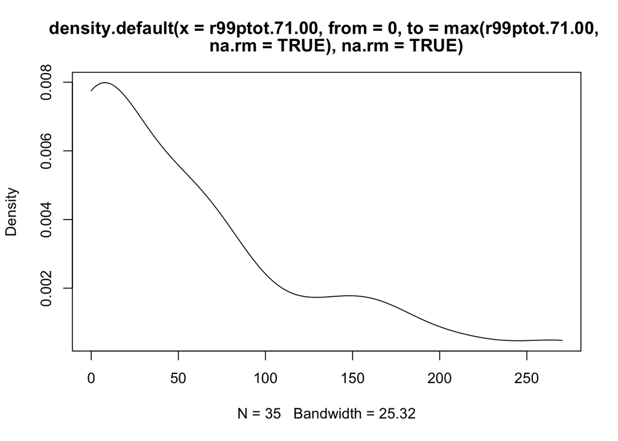

```r
# Compute pdf:
r99ptot.71.00.d<-density(r99ptot.71.00,na.rm=TRUE,from=0,
                         to=max(r99ptot.71.00,na.rm=TRUE))
plot(r99ptot.71.00.d)
```

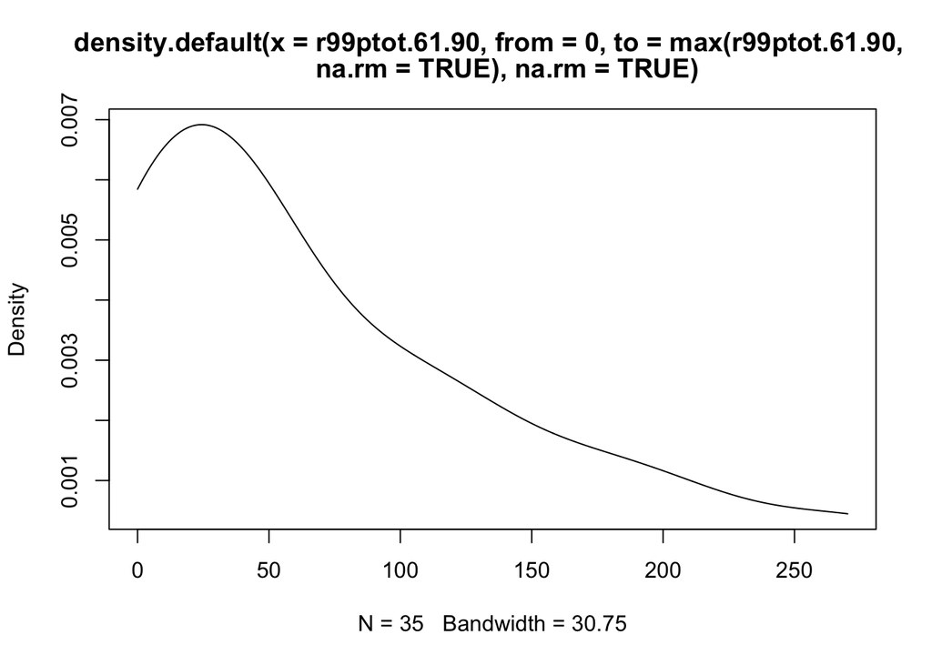

```r
r99ptot.61.90.d<-density(r99ptot.61.90,na.rm=TRUE,from=0,
                         to=max(r99ptot.61.90,na.rm=TRUE))
plot(r99ptot.61.90.d)
```

# Visualizing with `{ggplot2}` package

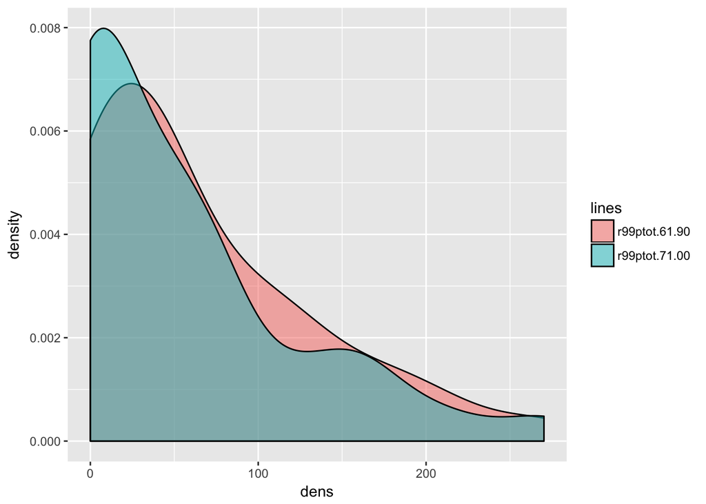

```r
library(ggplot2)
# build a dataframe:
n=length(r99ptot.71.00)
dat<-data.frame(
  dens=c(r99ptot.71.00,r99ptot.61.90),     lines=rep(c("r99ptot.71.00","r99ptot.61.90"),each=n)
  )

ggplot(dat, aes(x = dens, fill = lines)) + geom_density(alpha = 0.5)
```

# How to analyse a specific period

We use the `{dplyr}` package to subset data and we build again the `climdexInput` object setting the argument `max.missing.days=c(annual = 365,monthly = 31)` in order to allow the computation. In fact, the `climdexInput` object built from subsetted dataset is composed of the complete time series, where the values of days outside the period of interest are set to NA.

```r
library(dplyr)
# Let's say June-July-August-September:
JJAS.daily <- filter(Chirps, month==6 | month==7 | month==8 | month==9)
## summary(JJAS.daily)


# Create a climdexInput object:
PREC <- JJAS.daily$prec

PREC.DATES <- as.PCICt(do.call(paste, JJAS.daily[,c("year","month", "day")]),
                       format="%Y %m %d",cal="gregorian")

PREC.CLIMDEX <- climdexInput.raw(prec = PREC,
                                 prec.dates = PREC.DATES,
                                 base.range = c(1971,2000),
                                 northern.hemisphere = TRUE,
                                 max.missing.days = c(annual = 365,
                                                      monthly = 31))

climdex.r95ptot(PREC.CLIMDEX)
```

```
##     1981     1982     1983     1984     1985     1986     1987     1988
## 123.9153  85.8389  28.2332  60.8925 193.8586  96.2591  56.4576 183.1738
##     1989     1990     1991     1992     1993     1994     1995     1996
##  93.7203   0.0000  35.4896 211.4968  87.8871 300.7150  34.2049  87.3719
##     1997     1998     1999     2000     2001     2002     2003     2004
##  92.8665 122.4810 124.6032  62.6685 139.2760  27.0517 177.0089  27.2312
##     2005     2006     2007     2008     2009     2010     2011     2012
## 144.9007 166.5927 250.5355 141.9651  55.8779 268.9372  33.7278 299.4028
##     2013     2014     2015     2016     2017
## 199.4926  57.4597 369.5718 215.1158  55.5294
```